# Multidimensional Scaling

## 1 From distances to a map

## From travel times to a map

[interactive chart not shown]

MDS sees only the travel times and draws a ring in driving order. With a long wait at the construction site, the ring becomes a line.

## What MDS sees: the distance matrix \(\mathbf D\)

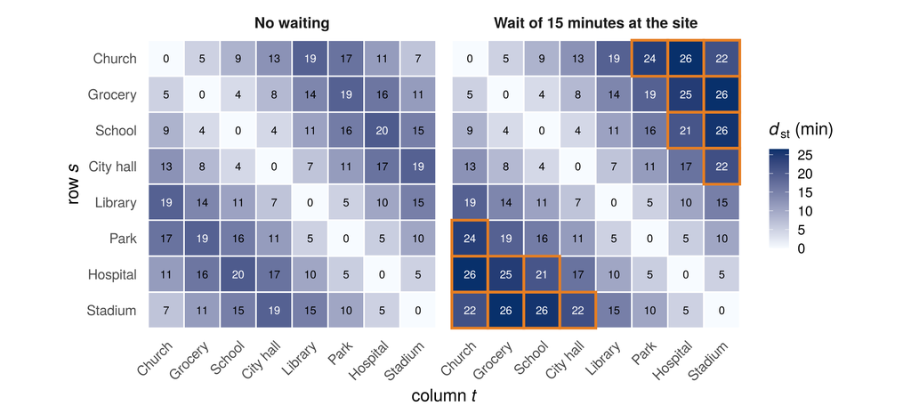

The entry \(d_{st}\) is the travel time between places \(s\) and \(t\). The outlined trips pass the construction site.

## Can we get a map back from \(\mathbf D\)?

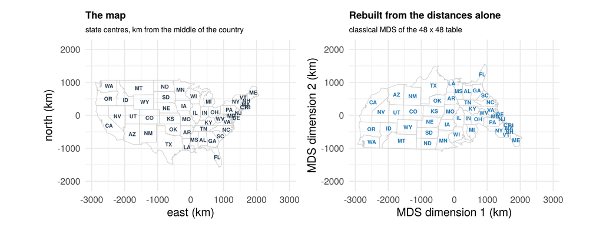

Here \(\mathbf D\) holds the 1,128 distances between the 48 state centres. MDS gets the shape right, but upside down.

## Every turn fits the same \(\mathbf D\)

[interactive chart not shown]

Turning the map changes no distance.

So \(\mathbf D\) cannot tell which way is north.

It fixes the map only up to a turn and a flip.

## In three dimensions: three angles

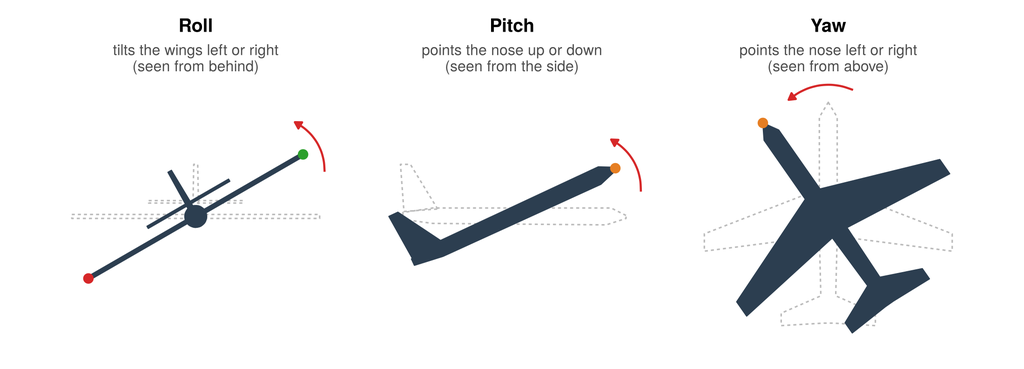

None of the three turns changes a distance. So three facts are needed to pin the plane down.

## 2 How MDS draws the map

## From distances to inner products

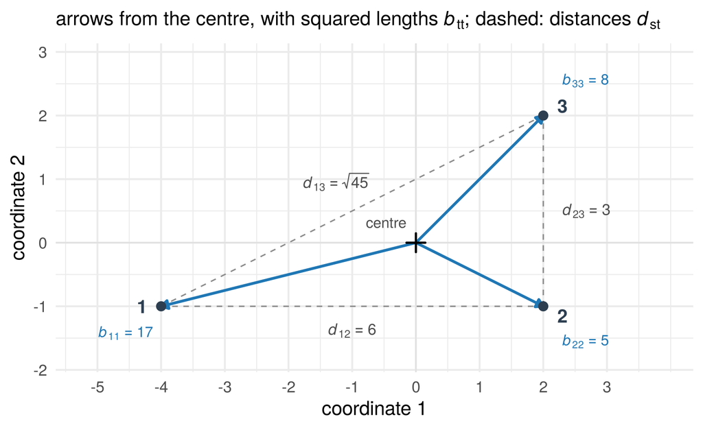

- The inner product multiplies the coordinates and adds them up, as in \(b_{13}=-8-2=-10\).
- Distances and inner products are linked, \(d_{st}^2=b_{ss}+b_{tt}-2b_{st}\).
- So the inner products \(\mathbf B\) follow from \(\mathbf D\) alone.

## MDS returns the PCA scores

[interactive chart not shown]

The eigenvectors of \(\mathbf B\) give the map. However the map is turned (left), its PCA scores stay put (right). They are exactly the map that MDS returns.

## The roommates need no first step

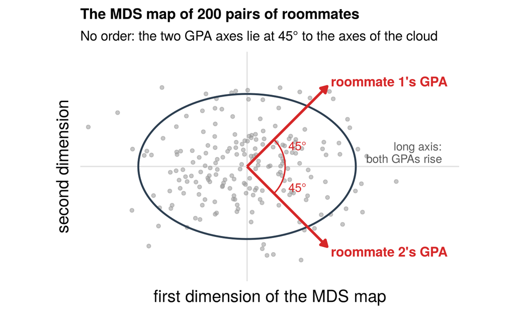

Random pairing gives the roommates no order.

So their GPA axes lie at 45° to the axes of the cloud, and the map alone gives the peer effect, 0.20.

With an order, as in Cholesky, the map must first be turned into place.

## 3 Other distances: profiles and text

## The states as profiles

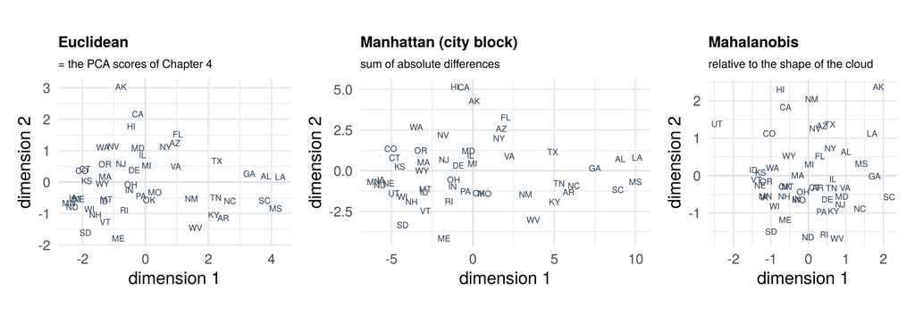

Each state is a point in six dimensions, one per indicator. Mahalanobis distances remove the correlations, so the cloud turns round.

## Distances from text

\(d_{st}\) is how many words apart \(s\) and \(t\) appear in a text, on average.

Coke and Pepsi are 3.2 words apart. Coke and runway are 22.6.

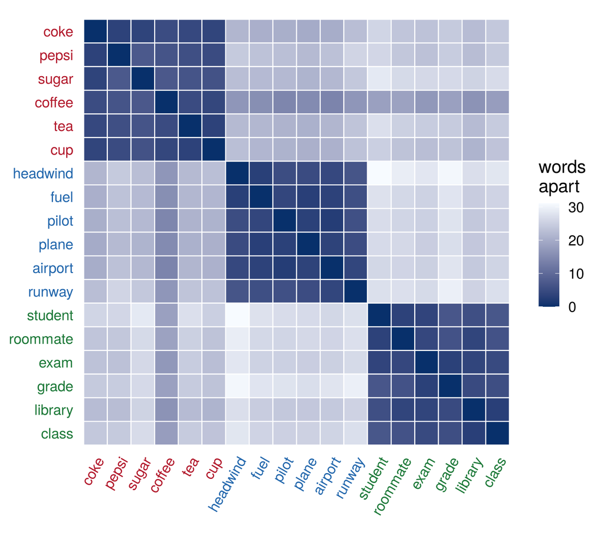

## The embedding

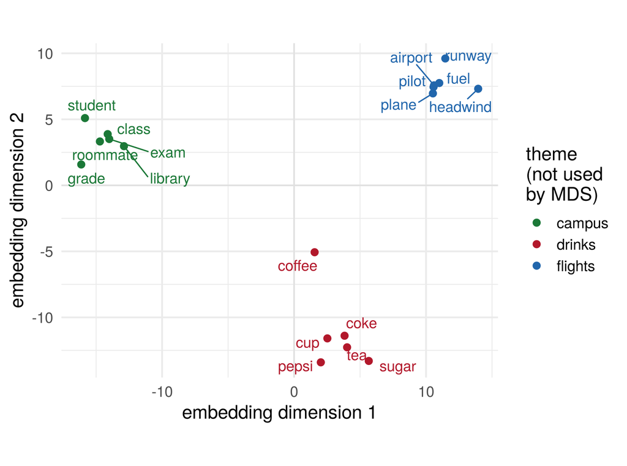

MDS turns these distances into coordinates, the **embedding**.

Each theme forms its own group. MDS was never told the themes.

One-hot encoding, by contrast, puts every two words the same distance apart.

## 4 When no map fits

## Four places on a loop: no map fits

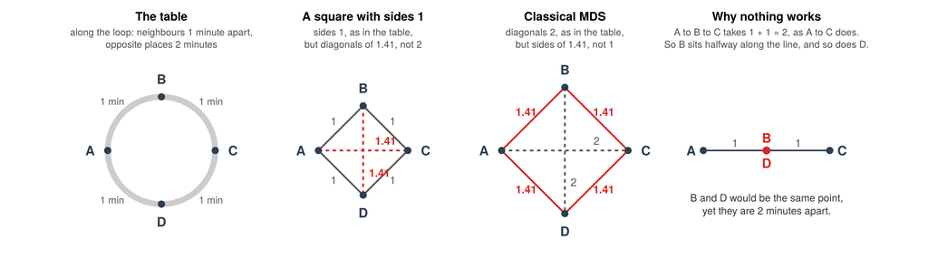

A square gets either the sides or the diagonals right, never both. No number of dimensions helps.

## Negative eigenvalues

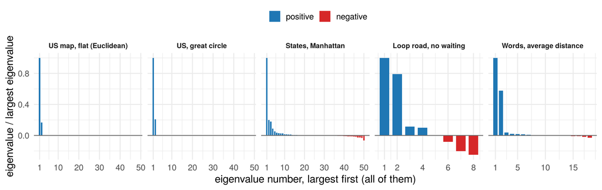

A negative eigenvalue means that no map reproduces the table exactly.

## The construction site in eigenvalues

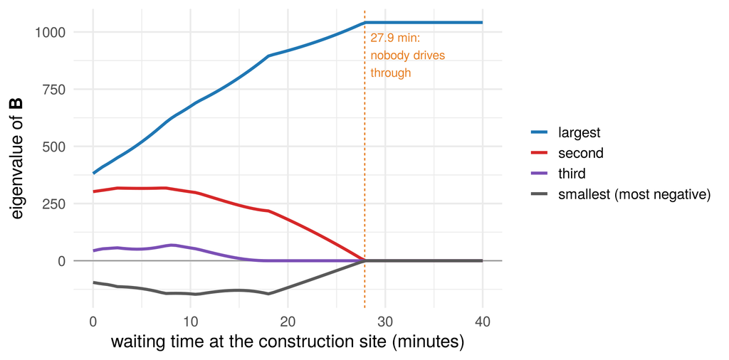

As the wait grows, one eigenvalue takes over. From 27.9 minutes on, a line fits exactly.

## The Shepard diagram

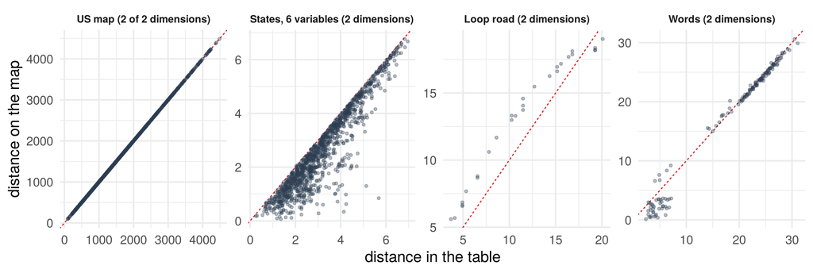

Each point is one pair of observations. On a perfect map, all points lie on the diagonal.

## Non-metric MDS

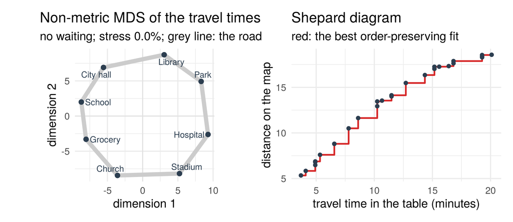

It keeps only the **order** of the distances. For the loop road, that order fits a circle exactly.

## Takeaways

- MDS turns a **distance matrix** into a map.
- The map is fixed only up to a turn and a flip. MDS returns the **PCA scores**.
- **Embeddings** are such maps for words.
- **Negative eigenvalues** mean that no map fits exactly.

MDS draws the map that a table of distances describes.